# 560-hw2-EDA

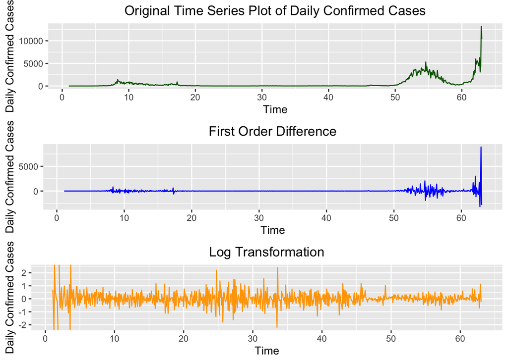

```r
#Generate a multifigure plots to compare detrend series with the original series. Differencing and log transformation are used for removing trend from time series data.
p1 = autoplot(ts_SP, color = "dark green") + ylab("Daily Confirmed Cases") + ggtitle("Original Time Series Plot of Daily Confirmed Cases") + theme(plot.title=element_text(hjust = 0.5))

p2 = autoplot(SP_1st_df, color = "blue" ) + ylab("Daily Confirmed Cases") + ggtitle("First Order Difference") + theme(plot.title=element_text(hjust = 0.5))

p3 = autoplot(diff(log(ts_SP)), color = "orange" ) + ylab("Daily Confirmed Cases") + ggtitle("Log Transformation") + theme(plot.title=element_text(hjust = 0.5))

grid.arrange(p1, p2, p3, ncol = 1)
```

The comparison among original series and detrend series: The First Order difference plot shows that differencing is a good method for moving trend from the time series data. The Log Transformation plot shows obvious stationary compared with the original time series.

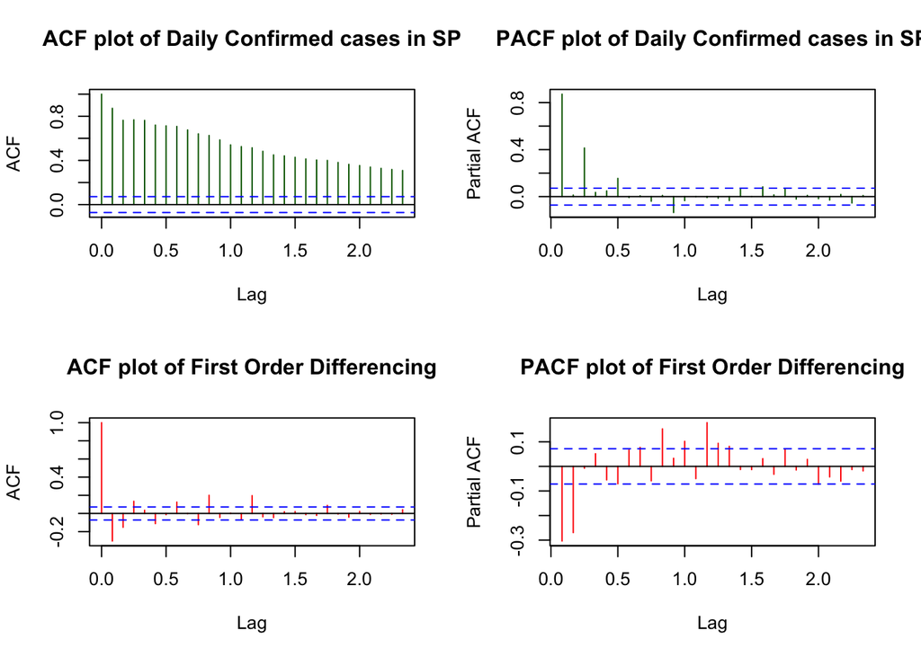

```r
#Generate a multifigure plots to compare ACF plot after detrending the series.
par(mfrow = c(2,2))
acf(ts_SP, main="ACF plot of Daily Confirmed cases in SP",col="dark green")
pacf(ts_SP, main="PACF plot of Daily Confirmed cases in SP",col="dark green")
acf(SP_1st_df, main="ACF plot of First Order Differencing",col="red")
pacf(SP_1st_df, main="PACF plot of First Order Differencing",col="red")
```

All ACF values in the original time series data are significant, indicating the time series is not stationary. The ACF plot of First Order Differencing shows that the data becomes stationary after detrending.

```r
adf.test(SP_1st_df)
```

```
##
##  Augmented Dickey-Fuller Test
##
## data:  SP_1st_df
## Dickey-Fuller = -4.2554, Lag order = 9, p-value = 0.01
## alternative hypothesis: stationary
```

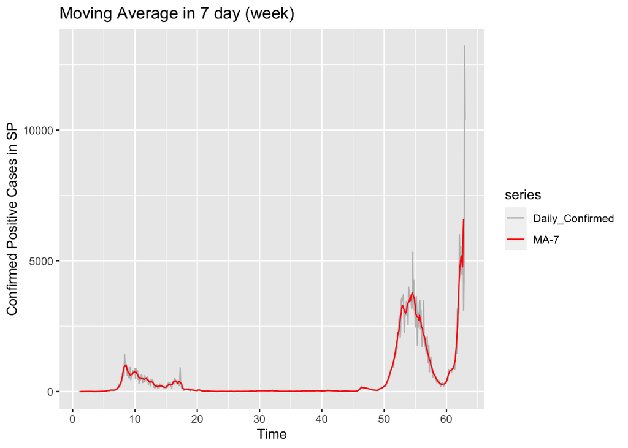

```r
# Moving Average in 3 Windows (in week/ month/ season)
#MA in week (7 days)
MA_7 <- autoplot(ts_SP, series="Daily_Confirmed") +
        autolayer(ma(ts_SP,7), series="MA-7") +
        xlab("Time") + ylab("Confirmed Positive Cases in SP") +
        ggtitle("Moving Average in 7 day (week)") +
        scale_colour_manual(values=c("Daily_Confirmed"="grey","MA-7"="red"),
                            breaks=c("Daily_Confirmed","MA-7"))

#MA in month (30 days)
MA_30 <- autoplot(ts_SP, series="Daily_Confirmed") +
        autolayer(ma(ts_SP,30), series="MA-30") +
        xlab("Time") + ylab("Confirmed Positive Cases in SP") +
        ggtitle("Moving Average in 30 days (month)") +
        scale_colour_manual(values=c("Daily_Confirmed"="grey","MA-30"="red"),
                            breaks=c("Daily_Confirmed","MA-30"))

#MA in season (91 days)
MA_91 <- autoplot(ts_SP, series="Daily_Confirmed") +
        autolayer(ma(ts_SP,91), series="MA-91") +
        xlab("Time") + ylab("Confirmed Positive Cases in SP") +
        ggtitle("Moving Average in 91 days (season)") +
        scale_colour_manual(values=c("Daily_Confirmed"="grey","MA-91"="red"),
                            breaks=c("Daily_Confirmed","MA-91"))

MA_7
```

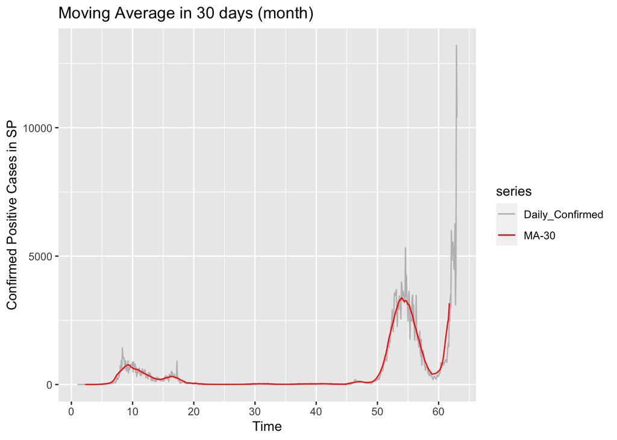

```r
MA_30
```

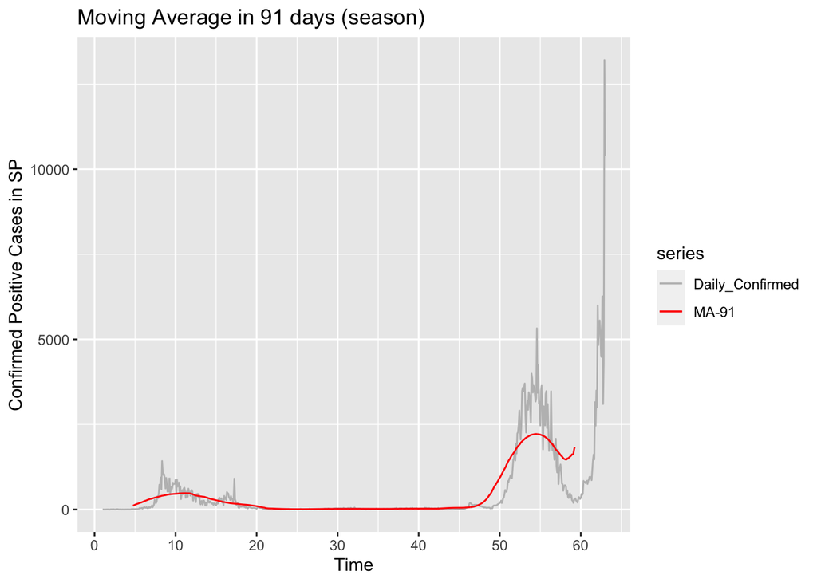

```r
MA_91
```